# Introduction to the rice package

# 8 Fractions

Sometimes, one needs to estimate a missing radiocarbon age from a sample which has C14 dates on both the entire sample and on fractions, but where one of the samples was too small to be dated. This can be used in for example soils separated into size fractions, or samples dated using both bulk and humic/humin fractions, where one of the samples turns out to be too small to be dated. This equation requires the bulk age, the ages of the dated fractions, and the carbon contents and weights of all fractions.

```r
Cs <- c(.02, .05, .03, .04) # carbon contents of each fraction
wghts <- c(5, 4, 2, .5) # weights for all fractions, e.g., in mg
ages <- c(130, 130, 130, NA) # ages of all fractions. The unmeasured one is NA
errors <- c(10, 12, 10, NA) # errors, unmeasured is NA
fractions(150, 20, Cs, wghts, ages, errors) # assuming a bulk age of 150 +- 20 C14 BP
```

```
## estimated C14 age of fraction 4: 518.8 +- 436.7
```

The above function can also be used to find the expected age of an entire sample, given the fractions and their ages - please type `?fractions` for more detail.

# 9 Calibration

Now on to calibration of radiocarbon dates. We can obtain the calibrated probability distributions from radiocarbon dates, e.g., one of 130 ± 10 C14 BP:

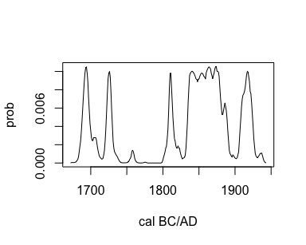

```r
calib.130 <- caldist(130, 10, BCAD=TRUE)
plot(calib.130, type="l")
```

It is also possible to find the likelihood of a single calendar year for our radiocarbon age, e.g., 145 cal BP:

```r
l.calib(145, 130, 10)
```

```
## [1] 0.0052052
```

To sample n=100 random values from a calibrated distribution (where the probability of a year being sampled is proportional to its calibrated height):

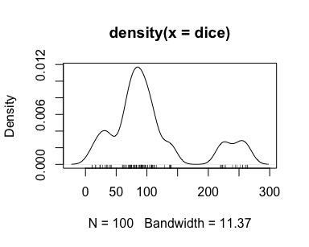

```r
dice <- r.calib(100, 130, 10)
plot(density(dice))
rug(dice)
```

For reporting purposes, calibrated dates are often reduced to their 95% highest posterior density (hpd) ranges (please report all, not just your favourite one!):

```r
hpd(calib.130)
```

```
##   from   to perc
## 1 1710 1684 13.0
## 2 1733 1719  8.1
## 3 1758 1758  0.1
## 4 1824 1803  8.3
## 5 1892 1832 50.8
## 6 1928 1905 14.8
```

Additionally, calibrated dates are often reduced to single point estimates. Note however how poor representations they are of the entire calibrated distribution!

```r
calib.2450 <- caldist(2450, 20)
plot(calib.2450, type="l")
points.2450 <- point.estimates(calib.2450)
points.2450
```

```
## weighted mean        median          mode      midpoint
##        2540.0        2512.5        2666.0        2531.5
```

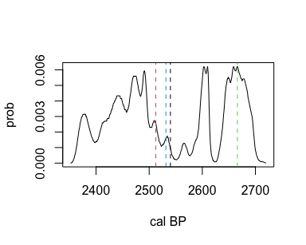

```r
abline(v=points.2450, col=1:4, lty=2)
```

Want a plot of the radiocarbon and calibrated distributions, together with their hpd ranges?

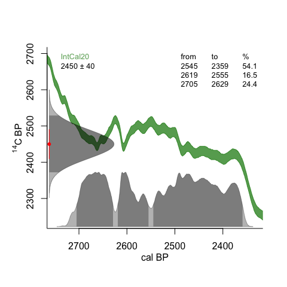

```r
calibrate(2450, 40)
```

Sometimes one would want to smooth a calibration curve to take into account the fact that material has accumulated over a certain time (e.g., a tree, or peat). To do so, a calibration curve can be smoothed to produce a tailor-made calibration curve, after which this one is used to calibrate the date:

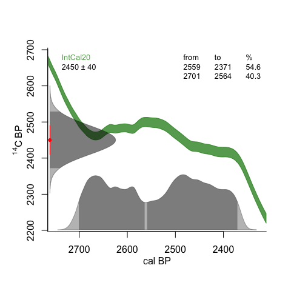

```r
mycurve <- smooth.ccurve(smooth=50)
calibrate(2450, 40, thiscurve=mycurve)
```

Calibrating ‘young’ radiocarbon dates (close to 0 C14 BP) can cause an error, because a bomb curve might be required to capture the youngest ages. Do not worry, there is an option to avoid that error:

```r
try(calibrate(130,30))
```

```
## Error in build.curve(y = age, er = error, cc = cc, thiscurve = thiscurve,  :
##   please provide a postbomb curve
```

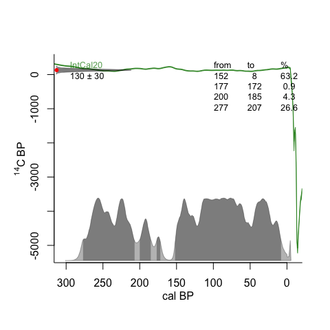

```r
calibrate(130, 30, bombalert=FALSE)
```

It is also possible to analyse the calibrated probability distributions, e.g. what is the probability (between 0 and 1) that the date stems from material that is of the age of 150 cal BP or younger? Or that it is older than that age?

```r
younger(150, 130, 10)
```

```
## [1] 0.7667408
```

```r
older(150, 130, 10)
```

```
## [1] 0.2332592
```

Or if you wish to calculate the probability covered between two age points (e.g., here between 300 and 150 cal BP):

```r
p.range(300, 150, 130, 10)
```

```
## [1] 0.2332592
```

The probabilities reported by `p.range` should be similar to those reported by the `hpd` function mentioned earlier. Any discrepancies can be explained by rounding errors in the calculations (e.g., hpd’s settings of `every`, `age.round` and `prob.round`).

At times there could be a lag in the date, for example if material has accumulated over decades. We can calibrate a date and then add a lag, by adding or subtracting either a normal distribution or a gamma one:

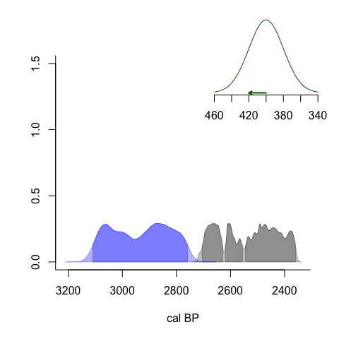

```
##   from   to perc
## 1 3110 2758   95
```

```r
push.normal(2450,40, 400,20)
```

# 10 Marine offsets

Dates on marine material will often have to be calibrated with the Marine20 calibration curve[^7], and many coastal locations will have an additional regional reservoir offset (deltaR) (Reimer and Reimer 2006)[^8]. The on-line database at http://calib.org/marine/ is very useful for this; it features the radiocarbon ages and deltaR of many shells of known collection date. The data from this database were downloaded (in August 2024) and can be queried. For example, a map can be drawn with all shell data within certain coordinates:

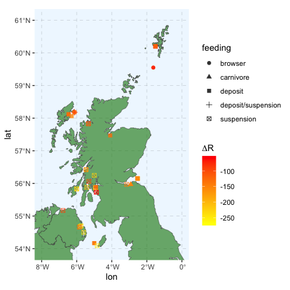

```r
myshells <- map.shells(S=54, W=-8, N=61, E=0) # the northern part of the UK
```

If you don’t have the R package ‘rnaturalearth’ installed, you will be asked to install it if possible, because the resulting maps will look much nicer. Same for the github package ‘rnaturalearthhires’, which produces more detailed maps.

The output can also be queried:

[figure not shown]

```
##       lon   lat  no taxonN   dR dSTD collected res res.error C14 er       lab
## 428 -3.15 55.97 524    146 -141   57      1851 386        58 511 57  SRR-1818
## 431 -5.00 54.17 527    125 -180   47      1890 334        47 444 47 SRR-1821a
## 432 -5.00 54.17 528    125 -129   63      1890 385        64 495 63 SRR-1821b
## 433 -6.00 55.83 529     48 -224   46      1890 290        46 400 46 SRR-1822a
## 434 -6.00 55.83 530     48 -233   52      1890 281        52 391 52 SRR-1822b
## 435 -5.33 57.83 531     90 -171   29      1900 346        30 442 29  SRR-357a
##                                                                                                                                                                                                                                                         ref
## 428 Harkness, D D,, 1983. The extent of the natural 14C deficiency in the coastal environment of the United Kingdom,. Journal of the European Study Group on Physical, Chemical and Mathematical Techniques Applied to Archaeology PACT 8 (IV.9):351-364.
## 431 Harkness, D D,, 1983. The extent of the natural 14C deficiency in the coastal environment of the United Kingdom,. Journal of the European Study Group on Physical, Chemical and Mathematical Techniques Applied to Archaeology PACT 8 (IV.9):351-364.
## 432 Harkness, D D,, 1983. The extent of the natural 14C deficiency in the coastal environment of the United Kingdom,. Journal of the European Study Group on Physical, Chemical and Mathematical Techniques Applied to Archaeology PACT 8 (IV.9):351-364.
## 433 Harkness, D D,, 1983. The extent of the natural 14C deficiency in the coastal environment of the United Kingdom,. Journal of the European Study Group on Physical, Chemical and Mathematical Techniques Applied to Archaeology PACT 8 (IV.9):351-364.
## 434 Harkness, D D,, 1983. The extent of the natural 14C deficiency in the coastal environment of the United Kingdom,. Journal of the European Study Group on Physical, Chemical and Mathematical Techniques Applied to Archaeology PACT 8 (IV.9):351-364.
## 435 Harkness, D D,, 1983. The extent of the natural 14C deficiency in the coastal environment of the United Kingdom,. Journal of the European Study Group on Physical, Chemical and Mathematical Techniques Applied to Archaeology PACT 8 (IV.9):351-364.
##                 taxon    feeding
## 428 Modiolus modiolus suspension
## 431   Littorina rudis    deposit
## 432   Littorina rudis    deposit
## 433  Chamelea gallina suspension
## 434  Chamelea gallina suspension
## 435   Dosinia exoleta suspension
```

```
## wmean -143.4, error is max of weighted uncertainty (5.3) & sdev (58.3): 58.3
```

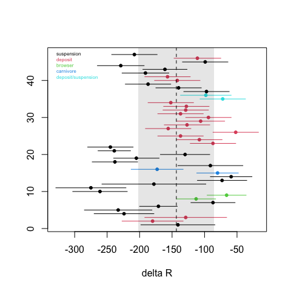

```
## [1] -143.4   58.3
```

```r
head(myshells)
shells.mean(myshells)
```

You can also extract say the 20 shells closest to a coordinate, e.g., 20 East and 30 South:

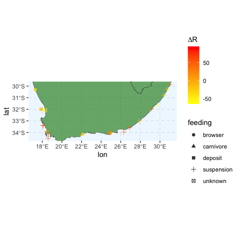

```
## wmean 5.1, error is max of weighted uncertainty (5.6) & sdev (49.5): 49.5
```

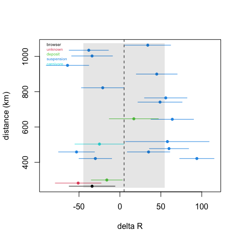

```
## [1]  5.1 49.5
```

```r
myshells <- find.shells(20, -30, 20)
shells.mean(myshells, distance=TRUE)
```

Instead of a static map, for `find.shells` and `map.shells` you can also request an interactive, browsable map, which will open in your Internet browser:

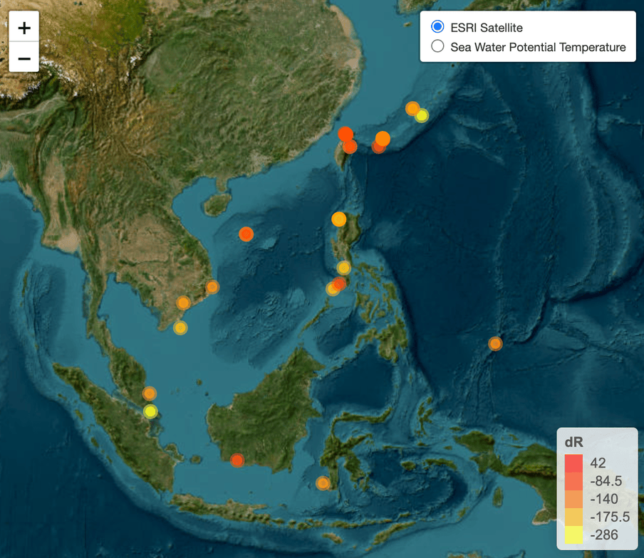

```r
find.shells(120, 10, 50, browse=TRUE)
```

# 11 More maps

The `p3k14c` R package[^9] contains over 175,000 radiocarbon dates (!) and is available on github[^10] (at c. 25 MB it’s too big for CRAN). Within `rice`, the data from `p13k14c` can be downloaded, plotted and browsed as follows:

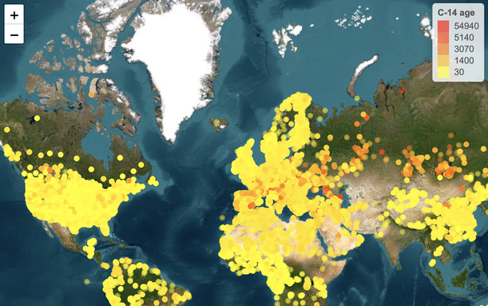

```r
p3k14c <- map.dates()
```

For another “database of databases”, have a look at c14bazAAR[^11] which is also on github (and too big for CRAN). After installing that package from github, type `c14bazAAR::db_info_table` to see a table of available databases.

# 12 Multiple calibrations

It is also possible to draw multiple calibrated distributions:

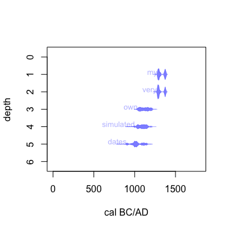

```r
set.seed(123)
dates <- sort(sample(500:2500,5))
errors <- .05*dates
depths <- 1:length(dates)
my.labels <- c("my", "very", "own", "simulated", "dates")
draw.dates(dates, errors, depths, BCAD=TRUE, labels=my.labels, age.lim=c(0, 1800))
```

or add them to an existing plot:

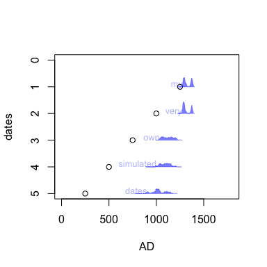

```r
plot(250*1:5, 5:1, xlim=c(0, 1800), ylim=c(5,0), xlab="AD", ylab="dates")
draw.dates(dates, errors, depths, BCAD=TRUE, add=TRUE, labels=my.labels, mirror=FALSE)
```

or get creative (inspired by Jocelyn Bell Burnell[^12], Joy Division[^13] and the Hallstatt Plateau[^14]):

[figure not shown]

```r
n <- 50; set.seed(42) # number of dates; always the same answer
from <- 2200; to <- 2900 # calendar age limits
y <- rnorm(n, 2620, 30) - 6*(1:n) # going through the Hallstatt Plateau

# set up an empty plot with black background
par(bg="black", mar=rep(1,4))
plot(0, type="n", xlim=c(to, from), ylim=c(n,-2), xlab="", ylab="")

for(i in 1:n) { # for each date...
  tmp <- draw.dates(y[i], 20, i, add=TRUE,
    mirror=FALSE, draw.hpd=FALSE, col="black", border=NA,
    peak=4, as.unit=TRUE) # distributions in black
  outline <- approx(tmp$ages, tmp$prob, seq(from, to, length=500), rule=2)
  y0 <- rnorm(500, i, 0.05) # make some noise
  lines(outline$x, y0-4*outline$y, col="white")
}
```

[^1]: Stuiver, R., Polach, H.A., 1977. Discussion: reporting of 14C data. *Radiocarbon* 19, 355-363 http://dx.doi.org/10.1017/S0033822200003672
[^2]: Reimer, P.J., Brown, T.A., Reimer, R.W., 2004. Discussion: reporting and calibration of post-bomb 14C Data. *Radiocarbon* 46, 1299-1304 http://dx.doi.org/10.1017/S0033822200033154
[^3]: Millard, R., 2014. Conventions for reporting radiocarbon determinations. *Radiocarbon* 56, 555-559 http://dx.doi.org/10.2458/56.17455
[^4]: Reimer, P.J., et al., 2020. The IntCal20 Northern Hemisphere radiocarbon age calibration curve (0-55 cal kBP). *Radiocarbon* 62, 725-757 http://dx.doi.org/10.1017/S0033822200032999
[^5]: Ward, G.K., Wilson, S., 1978. Procedures for comparing and combining radiocarbon age determinations: A critique. *Archaeometry* 20, 19-31 http://dx.doi.org/10.1111/j.1475-4754.1978.tb00208.x
[^6]: Damon, P., et al., 1989. Radiocarbon dating of the Shroud of Turin. *Nature* 337, 611–615. https://doi.org/10.1038/337611a0
[^7]: Heaton, T.J., et al., 2020. Marine20-the marine radiocarbon age calibration curve (0-55,000 cal BP). *Radiocarbon* 62, 779-820 http://dx.doi.org/10.1017/RDC.2020.68
[^8]: Reimer, P.J., Reimer, R.W., 2006. A marine reservoir correction database and on-line interface. *Radiocarbon* 43, 461-463. http://dx.doi.org/10.1017/S0033822200038339
[^9]: Bird, D., Miranda, L., Vander Linden, M. et al., 2022. p3k14c, a synthetic global database of archaeological radiocarbon dates. *Scientific Data* 9, 27. https://doi.org/10.1038/s41597-022-01118-7
[^10]: https://github.com/people3k/p3k14c
[^11]: https://github.com/ropensci/c14bazAAR
[^12]: https://www.cam.ac.uk/stories/journeysofdiscovery-pulsars
[^13]: https://www.radiox.co.uk/artists/joy-division/unknown-pleasures-album-cover-meaning/
[^14]: https://en.wikipedia.org/wiki/Hallstatt_plateau